# 利用数据分析影响预期寿命的因素

> 世界卫生组织 (WHO) 下属的全球健康观察站 (GHO) 数据存储库跟踪所有国家的健康状况以及许多其他相关因素。这些数据集向公众开放，用于生命健康数据分析。该数据集包括193 个国家的预期寿命和健康因素，相关的数据来自世卫组织数据库网站，其相应的经济数据来自联合国网站。

**试根据数据解决以下问题：**

> 1. 哪些预测变量实际上会影响预期寿命？
> 2. 婴儿和成人死亡率如何影响预期寿命？
> 3. 预期寿命与饮食习惯，生活方式，运动，吸烟等有何关系？
> 4. 学校教育对人类寿命有何影响？
> 5. 预期寿命与饮酒有正面还是负面的关系？

> 项目链接 [Life Expectancy (WHO)](https://www.kaggle.com/kumarajarshi/life-expectancy-who)

**使用 python 语言，编辑器为 jupyter notebook**

```python
import numpy as np
import pandas as pd
import matplotlib.pyplot as plt
import seaborn as sns
import os
```

### 导入数据

```python
life_data = pd.read_csv('Life Expectancy Data.csv')
life_data
```

|  | Country | Year | Status | Life expectancy | Adult Mortality | infant deaths | Alcohol | percentage expenditure | Hepatitis B | Measles | ... | Polio | Total expenditure | Diphtheria | HIV/AIDS | GDP | Population | thinness 1-19 years | thinness 5-9 years | Income composition of resources | Schooling |
| --- | --- | --- | --- | --- | --- | --- | --- | --- | --- | --- | --- | --- | --- | --- | --- | --- | --- | --- | --- | --- | --- |
| 0 | Afghanistan | 2015 | Developing | 65.0 | 263.0 | 62 | 0.01 | 71.279624 | 65.0 | 1154 | ... | 6.0 | 8.16 | 65.0 | 0.1 | 584.259210 | 33736494.0 | 17.2 | 17.3 | 0.479 | 10.1 |
| 1 | Afghanistan | 2014 | Developing | 59.9 | 271.0 | 64 | 0.01 | 73.523582 | 62.0 | 492 | ... | 58.0 | 8.18 | 62.0 | 0.1 | 612.696514 | 327582.0 | 17.5 | 17.5 | 0.476 | 10.0 |
| 2 | Afghanistan | 2013 | Developing | 59.9 | 268.0 | 66 | 0.01 | 73.219243 | 64.0 | 430 | ... | 62.0 | 8.13 | 64.0 | 0.1 | 631.744976 | 31731688.0 | 17.7 | 17.7 | 0.470 | 9.9 |
| 3 | Afghanistan | 2012 | Developing | 59.5 | 272.0 | 69 | 0.01 | 78.184215 | 67.0 | 2787 | ... | 67.0 | 8.52 | 67.0 | 0.1 | 669.959000 | 3696958.0 | 17.9 | 18.0 | 0.463 | 9.8 |
| 4 | Afghanistan | 2011 | Developing | 59.2 | 275.0 | 71 | 0.01 | 7.097109 | 68.0 | 3013 | ... | 68.0 | 7.87 | 68.0 | 0.1 | 63.537231 | 2978599.0 | 18.2 | 18.2 | 0.454 | 9.5 |
| ... | ... | ... | ... | ... | ... | ... | ... | ... | ... | ... | ... | ... | ... | ... | ... | ... | ... | ... | ... | ... | ... |
| 2933 | Zimbabwe | 2004 | Developing | 44.3 | 723.0 | 27 | 4.36 | 0.000000 | 68.0 | 31 | ... | 67.0 | 7.13 | 65.0 | 33.6 | 454.366654 | 12777511.0 | 9.4 | 9.4 | 0.407 | 9.2 |
| 2934 | Zimbabwe | 2003 | Developing | 44.5 | 715.0 | 26 | 4.06 | 0.000000 | 7.0 | 998 | ... | 7.0 | 6.52 | 68.0 | 36.7 | 453.351155 | 12633897.0 | 9.8 | 9.9 | 0.418 | 9.5 |
| 2935 | Zimbabwe | 2002 | Developing | 44.8 | 73.0 | 25 | 4.43 | 0.000000 | 73.0 | 304 | ... | 73.0 | 6.53 | 71.0 | 39.8 | 57.348340 | 125525.0 | 1.2 | 1.3 | 0.427 | 10.0 |
| 2936 | Zimbabwe | 2001 | Developing | 45.3 | 686.0 | 25 | 1.72 | 0.000000 | 76.0 | 529 | ... | 76.0 | 6.16 | 75.0 | 42.1 | 548.587312 | 12366165.0 | 1.6 | 1.7 | 0.427 | 9.8 |
| 2937 | Zimbabwe | 2000 | Developing | 46.0 | 665.0 | 24 | 1.68 | 0.000000 | 79.0 | 1483 | ... | 78.0 | 7.10 | 78.0 | 43.5 | 547.358878 | 12222251.0 | 11.0 | 11.2 | 0.434 | 9.8 |

2938 rows × 22 columns

*部分名词解释：Hepatitis B 乙型肝炎，Measles 麻疹，Polio 小儿麻痹症，Diththeria 白喉，HIV/AIDS 艾滋病*

### 取全球平均值代表整体情况

```python
life_datadr = life_data.drop(['Country', 'Status'], axis = 1)
life_data_globle = life_datadr.groupby('Year').mean().round(2)
#life_data_globle
```

### 相关矩阵

```python
corr_globle = life_data_globle.corr().round(2)
corr_globle
```

|  | Life expectancy | Adult Mortality | infant deaths | Alcohol | percentage expenditure | Hepatitis B | Measles | BMI | under-five deaths | Polio | Total expenditure | Diphtheria | HIV/AIDS | GDP | Population | thinness 1-19 years | thinness 5-9 years | Income composition of resources | Schooling |
| --- | --- | --- | --- | --- | --- | --- | --- | --- | --- | --- | --- | --- | --- | --- | --- | --- | --- | --- | --- |
| Life expectancy | 1.00 | -0.88 | -0.99 | -0.28 | 0.25 | 0.84 | -0.85 | 0.94 | -0.99 | 0.80 | 0.77 | 0.87 | -0.98 | 0.75 | 0.23 | -0.89 | -0.90 | 0.97 | 0.98 |
| Adult Mortality | -0.88 | 1.00 | 0.86 | 0.40 | -0.19 | -0.65 | 0.68 | -0.83 | 0.87 | -0.65 | -0.65 | -0.75 | 0.88 | -0.57 | -0.23 | 0.80 | 0.81 | -0.85 | -0.84 |
| infant deaths | -0.99 | 0.86 | 1.00 | 0.26 | -0.26 | -0.85 | 0.87 | -0.93 | 1.00 | -0.81 | -0.77 | -0.89 | 0.97 | -0.75 | -0.26 | 0.88 | 0.89 | -0.97 | -0.98 |
| Alcohol | -0.28 | 0.40 | 0.26 | 1.00 | -0.33 | -0.04 | 0.02 | -0.28 | 0.26 | -0.03 | -0.04 | -0.05 | 0.34 | -0.24 | -0.33 | 0.39 | 0.28 | -0.19 | -0.19 |
| percentage expenditure | 0.25 | -0.19 | -0.26 | -0.33 | 1.00 | 0.52 | -0.43 | 0.03 | -0.25 | 0.54 | -0.31 | 0.49 | -0.19 | 0.74 | 0.43 | -0.13 | -0.16 | 0.36 | 0.33 |
| Hepatitis B | 0.84 | -0.65 | -0.85 | -0.04 | 0.52 | 1.00 | -0.92 | 0.72 | -0.84 | 0.92 | 0.54 | 0.94 | -0.76 | 0.84 | 0.30 | -0.58 | -0.65 | 0.90 | 0.89 |
| Measles | -0.85 | 0.68 | 0.87 | 0.02 | -0.43 | -0.92 | 1.00 | -0.77 | 0.86 | -0.94 | -0.58 | -0.94 | 0.77 | -0.80 | -0.24 | 0.62 | 0.71 | -0.92 | -0.91 |
| BMI | 0.94 | -0.83 | -0.93 | -0.28 | 0.03 | 0.72 | -0.77 | 1.00 | -0.94 | 0.69 | 0.84 | 0.79 | -0.94 | 0.56 | 0.04 | -0.89 | -0.91 | 0.90 | 0.90 |
| under-five deaths | -0.99 | 0.87 | 1.00 | 0.26 | -0.25 | -0.84 | 0.86 | -0.94 | 1.00 | -0.80 | -0.78 | -0.88 | 0.97 | -0.74 | -0.27 | 0.89 | 0.90 | -0.97 | -0.98 |
| Polio | 0.80 | -0.65 | -0.81 | -0.03 | 0.54 | 0.92 | -0.94 | 0.69 | -0.80 | 1.00 | 0.44 | 0.93 | -0.70 | 0.80 | 0.27 | -0.56 | -0.64 | 0.90 | 0.87 |
| Total expenditure | 0.77 | -0.65 | -0.77 | -0.04 | -0.31 | 0.54 | -0.58 | 0.84 | -0.78 | 0.44 | 1.00 | 0.56 | -0.77 | 0.26 | -0.02 | -0.76 | -0.75 | 0.68 | 0.73 |
| Diphtheria | 0.87 | -0.75 | -0.89 | -0.05 | 0.49 | 0.94 | -0.94 | 0.79 | -0.88 | 0.93 | 0.56 | 1.00 | -0.79 | 0.83 | 0.23 | -0.69 | -0.77 | 0.94 | 0.93 |
| HIV/AIDS | -0.98 | 0.88 | 0.97 | 0.34 | -0.19 | -0.76 | 0.77 | -0.94 | 0.97 | -0.70 | -0.77 | -0.79 | 1.00 | -0.69 | -0.17 | 0.93 | 0.93 | -0.92 | -0.93 |
| GDP | 0.75 | -0.57 | -0.75 | -0.24 | 0.74 | 0.84 | -0.80 | 0.56 | -0.74 | 0.80 | 0.26 | 0.83 | -0.69 | 1.00 | 0.42 | -0.57 | -0.57 | 0.80 | 0.79 |
| Population | 0.23 | -0.23 | -0.26 | -0.33 | 0.43 | 0.30 | -0.24 | 0.04 | -0.27 | 0.27 | -0.02 | 0.23 | -0.17 | 0.42 | 1.00 | -0.08 | 0.02 | 0.27 | 0.30 |
| thinness 1-19 years | -0.89 | 0.80 | 0.88 | 0.39 | -0.13 | -0.58 | 0.62 | -0.89 | 0.89 | -0.56 | -0.76 | -0.69 | 0.93 | -0.57 | -0.08 | 1.00 | 0.97 | -0.82 | -0.84 |
| thinness 5-9 years | -0.90 | 0.81 | 0.89 | 0.28 | -0.16 | -0.65 | 0.71 | -0.91 | 0.90 | -0.64 | -0.75 | -0.77 | 0.93 | -0.57 | 0.02 | 0.97 | 1.00 | -0.85 | -0.86 |
| Income composition of resources | 0.97 | -0.85 | -0.97 | -0.19 | 0.36 | 0.90 | -0.92 | 0.90 | -0.97 | 0.90 | 0.68 | 0.94 | -0.92 | 0.80 | 0.27 | -0.82 | -0.85 | 1.00 | 0.99 |
| Schooling | 0.98 | -0.84 | -0.98 | -0.19 | 0.33 | 0.89 | -0.91 | 0.90 | -0.98 | 0.87 | 0.73 | 0.93 | -0.93 | 0.79 | 0.30 | -0.84 | -0.86 | 0.99 | 1.00 |

### 可视化

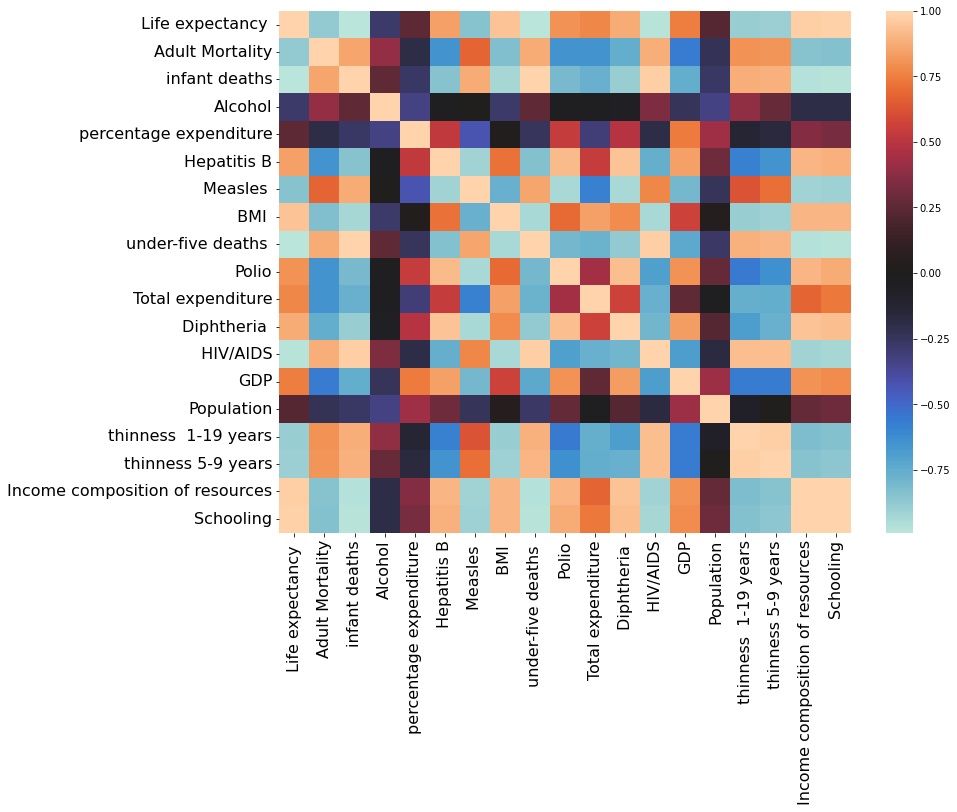

```python
fig = plt.figure(figsize=(12.8, 9.6))# 将画布放大到两倍，默认大小是640x480
sns.heatmap(corr_globle, center=0) # searborn 简单热力图

plt.tick_params(labelsize=16) #刻度值大小
```

相关系数 r (R=|r|) 的一般意义：

| R的取值范围 | 相关程度 |
| --- | --- |
| 0.00-0.19 | 极低相关 |
| 0.20-0.39 | 低度相关 |
| 0.40-0.69 | 中度相关 |
| 0.70-0.89 | 高度相关 |
| 0.90-1.00 | 极高相关 |

## 其他可行的探索和可能的问题

- 人口稠密的国家是否倾向于降低预期寿命？
- 免疫覆盖率对预期寿命有和影响？
- 预期寿命低于 65 的国家是否应该增加其医疗保健支出以改善其平均寿命？
- 预期寿命与各种影响因素的相关程度在发达国家和发展中国家中有何异同？
- 使用全球中位数是否更具有代表性？
- ......